# Introduction to PMM2: Polynomial Maximization Method

Serhii Zabolotnii

2026-03-20

## The Problem: When OLS Falls Short

Ordinary Least Squares (OLS) is the workhorse of regression analysis, providing **Best Linear Unbiased Estimators (BLUE)** under the Gauss-Markov assumptions. However, when error distributions deviate from normality—particularly when they exhibit **skewness**—OLS estimates, while still unbiased, lose statistical efficiency. This means:

- **Higher variance** in parameter estimates
- **Wider confidence intervals**
- **Reduced statistical power** for hypothesis tests

### Practical Implications

Consider scenarios where non-normal errors are common:

- **Financial data**: Asset returns often have heavy tails and skewness
- **Environmental measurements**: Contamination levels, precipitation
- **Biomedical applications**: Biological markers with asymmetric distributions
- **Engineering**: Measurement errors from physical processes

In these contexts, relying solely on OLS can lead to **suboptimal inference**.

## The Solution: Polynomial Maximization Method (PMM2)

The **Polynomial Maximization Method of order 2 (PMM2)** is a moment-based estimation technique that leverages higher-order moments of residuals to achieve:

1. **Lower variance** estimates compared to OLS when errors are non-Gaussian
2. **Robustness** to skewness and kurtosis in error distributions
3. **Asymptotic efficiency** gains validated through Monte Carlo studies

### Theoretical Foundation

PMM2 works by constructing a system of polynomial equations based on central moments:

$$Z_j(\beta) = \sum_{i=1}^{n} x_{ij} \left[ A \cdot \hat{y}_i^2 + B \cdot
\hat{y}_i + C \right] = 0$$

where:

- $A = m_3$ (third central moment)
- $B = m_4 - m_2^2 - 2m_3 y_i$ (involves fourth moment)
- $C = m_3 y_i^2 - (m_4 - m_2^2) y_i - m_2 m_3$

The algorithm iteratively solves this system using a gradient-based approach, starting from OLS estimates.

**Reference:** Zabolotnii et al. (2018) - “Polynomial Estimation of Linear Regression Parameters for the Asymmetric PDF of Errors” (Springer, AUTOMATION 2018)

## Getting Started with EstemPMM

Let’s explore PMM2 with practical examples using the `EstemPMM` package.

```r
library(EstemPMM)
set.seed(123)
```

## Example 1: Simple Linear Regression with Skewed Errors

We’ll simulate data where errors follow a **skewed distribution** (using $\chi^2$) to demonstrate PMM2’s advantages.

### Data Generation

```r
# Sample size
n <- 200

# Generate predictor
x <- rnorm(n, mean = 5, sd = 2)

# True parameters
beta_0 <- 10
beta_1 <- 2.5

# Generate highly skewed errors using chi-squared distribution
# (chi-square with df=3 has skewness ~ 1.63)
errors <- rchisq(n, df = 3) - 3  # Center to have mean ~ 0

# Response variable
y <- beta_0 + beta_1 * x + errors

# Create data frame
dat <- data.frame(y = y, x = x)
```

### Visualize Error Distribution

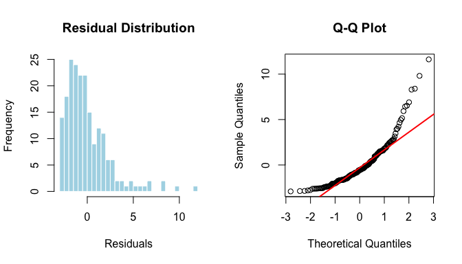

```r
# Fit OLS to get residuals for visualization
fit_ols_temp <- lm(y ~ x, data = dat)
residuals_ols <- residuals(fit_ols_temp)

# Plot histogram of residuals
par(mfrow = c(1, 2))
hist(residuals_ols, breaks = 30, main = "Residual Distribution",
     xlab = "Residuals", col = "lightblue", border = "white")
qqnorm(residuals_ols, main = "Q-Q Plot")
qqline(residuals_ols, col = "red", lwd = 2)
```

```r
par(mfrow = c(1, 1))

# Calculate skewness and kurtosis
cat(sprintf("Skewness: %.3f\n", pmm_skewness(residuals_ols)))
```

```
#> Skewness: 1.865
```

```r
cat(sprintf("Excess Kurtosis: %.3f\n", pmm_kurtosis(residuals_ols) - 3))
```

```
#> Excess Kurtosis: 1.710
```

The histogram and Q-Q plot clearly show **right skewness**, violating the normality assumption that underpins OLS optimality.

### Model Fitting: PMM2 vs OLS

```r
# Fit PMM2 model
fit_pmm2 <- lm_pmm2(y ~ x, data = dat, verbose = FALSE)

# Fit OLS model for comparison
fit_ols <- lm(y ~ x, data = dat)

# Display coefficients
cat("=== OLS Estimates ===\n")
```

```
#> === OLS Estimates ===
```

```r
print(coef(fit_ols))
```

```
#> (Intercept)           x
#>   10.188412    2.423676
```

```r
cat("\n=== PMM2 Estimates ===\n")
```

```
#>
#> === PMM2 Estimates ===
```

```r
print(coef(fit_pmm2))
```

```
#> [1] 9.980738 2.465210
```

```r
cat("\n=== True Values ===\n")
```

```
#>
#> === True Values ===
```

```r
cat("Intercept:", beta_0, "\n")
```

```
#> Intercept: 10
```

```r
cat("Slope:    ", beta_1, "\n")
```

```
#> Slope:     2.5
```

### Bootstrap Inference for Variance Comparison

To rigorously compare estimator efficiency, we use **bootstrap inference**:

```r
# Perform bootstrap inference
boot_results <- pmm2_inference(fit_pmm2, formula = y ~ x, data = dat,
                               B = 500)

# Display summary with confidence intervals
summary(boot_results)
```

```
#>     Estimate       Std.Error          t.value         p.value     conf.low
#>  Min.   :2.465   Min.   :0.06404   Min.   :27.25   Min.   :0   Min.   :2.348
#>  1st Qu.:4.344   1st Qu.:0.13959   1st Qu.:30.06   1st Qu.:0   1st Qu.:4.072
#>  Median :6.223   Median :0.21514   Median :32.87   Median :0   Median :5.796
#>  Mean   :6.223   Mean   :0.21514   Mean   :32.87   Mean   :0   Mean   :5.796
#>  3rd Qu.:8.102   3rd Qu.:0.29069   3rd Qu.:35.68   3rd Qu.:0   3rd Qu.:7.520
#>  Max.   :9.981   Max.   :0.36624   Max.   :38.49   Max.   :0   Max.   :9.244
#>    conf.high
#>  Min.   : 2.597
#>  1st Qu.: 4.615
#>  Median : 6.634
#>  Mean   : 6.634
#>  3rd Qu.: 8.652
#>  Max.   :10.670
```

## Example 2: Multiple Regression

PMM2 extends naturally to multiple predictors.

```r
# Generate multiple predictors
n <- 250
x1 <- rnorm(n, mean = 0, sd = 1)
x2 <- runif(n, min = -2, max = 2)
x3 <- rexp(n, rate = 0.5)

# True model
beta <- c(5, 1.2, -0.8, 2.0)  # Intercept, x1, x2, x3
errors <- rt(n, df = 4)  # t-distribution with heavy tails

y <- beta[1] + beta[2]*x1 + beta[3]*x2 + beta[4]*x3 + errors

# Create data frame
dat_multi <- data.frame(y = y, x1 = x1, x2 = x2, x3 = x3)

# Fit models
fit_pmm2_multi <- lm_pmm2(y ~ x1 + x2 + x3, data = dat_multi, verbose = FALSE)
fit_ols_multi <- lm(y ~ x1 + x2 + x3, data = dat_multi)

# Compare coefficients
comparison <- data.frame(
  Parameter = c("Intercept", "x1", "x2", "x3"),
  True = beta,
  OLS = coef(fit_ols_multi),
  PMM2 = coef(fit_pmm2_multi)
)

print(comparison, row.names = FALSE)
```

```
#>  Parameter True        OLS      PMM2
#>  Intercept  5.0  4.9484846  4.939106
#>         x1  1.2  1.2531710  1.249675
#>         x2 -0.8 -0.8080797 -0.792286
#>         x3  2.0  2.0101585  2.014457
```

## Example 3: Polynomial Regression

PMM2 handles polynomial terms seamlessly.

```r
# Generate data with quadratic relationship
n <- 200
x <- seq(-3, 3, length.out = n)
errors <- rchisq(n, df = 5) - 5

# True quadratic model: y = 2 + 3x - 0.5x^2
y <- 2 + 3*x - 0.5*x^2 + errors

dat_poly <- data.frame(y = y, x = x)

# Fit polynomial model
fit_pmm2_poly <- lm_pmm2(y ~ x + I(x^2), data = dat_poly, verbose = FALSE)

# Summary
summary(fit_pmm2_poly, formula = y ~ x + I(x^2), data = dat_poly)
```

```
#> PMM2 estimation results
#> Call:
#> lm_pmm2(formula = y ~ x + I(x^2), data = dat_poly, verbose = FALSE)
#>
#> Coefficients:
#> [1]  2.0897269  2.8725555 -0.4779162
#>
#> Central moments of initial residuals:
#>   m2 = 10.05743
#>   m3 = 37.45091
#>   m4 = 489.7792
#>
#> Theoretical characteristics of PMM2 (S = 2):
#>   c3 = 1.174172
#>   c4 = 1.842015
#>   g  = 0.6411572  (expected ratio Var[PMM2]/Var[OLS])
#>
#> Algorithm information:
#>   Convergence status: TRUE
#>   Iterations: 3
#>
#> Approximate statistical inference via bootstrap (B=100):
#>     Estimate  Std.Error   t.value      p.value   conf.low  conf.high
#> 1  2.0897269 0.28555149  7.318214 2.513545e-13  1.5799690  2.6122483
#> 2  2.8725555 0.09797060 29.320586 0.000000e+00  2.6892140  3.0583990
#> 3 -0.4779162 0.06130577 -7.795616 6.439294e-15 -0.5863997 -0.3492109
```

## Diagnostic Plots

PMM2 provides standard diagnostic methods:

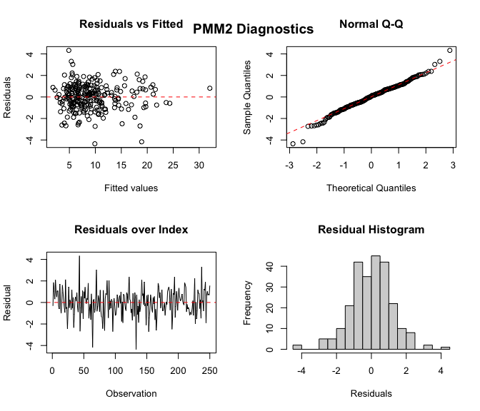

```r
# Generate diagnostic plots
plot(fit_pmm2_multi)
title("PMM2 Diagnostics")
```

## Comparing PMM2 with OLS: Monte Carlo Evidence

Based on simulation studies documented in the package:

| Model | Sample Size | MSE(PMM2) / MSE(OLS) | Variance Reduction |
| --- | --- | --- | --- |
| MA(1) | 200 / 1000 | 0.85 / 0.77 | 15-23% |
| MA(2) | 200 / 1000 | 0.68 / 0.74 | 26-32% |
| ARMA(1,1) | 200 / 1000 | 0.70 / 0.55 | 30-45% |
| ARIMA(1,1,1) | 300 / 1000 | 0.76 / 0.48 | 24-52% |

These ratios **less than 1.0** confirm that PMM2 achieves **lower Mean Squared Error** compared to classical methods (CSS/OLS) when errors deviate from normality.

## When to Use PMM2

**Use PMM2 when:**

- Error distributions exhibit **skewness** or **heavy tails**
- You need **more precise estimates** than OLS provides
- Working with **financial, environmental, or biomedical data** where non-normality is common
- Sample sizes are **moderate to large** (n ≥ 100 recommended)

**Stick with OLS when:**

- Errors are approximately **Gaussian**
- Sample sizes are **very small** (n < 50)
- Computational simplicity is paramount
- You need unbiased estimates regardless of efficiency

## Practical Recommendations

1. **Always fit OLS first** as a baseline comparison
2. **Check residual diagnostics** to assess non-normality
3. **Use bootstrap inference** (`pmm2_inference()`) for robust confidence intervals
4. **Compare standard errors** between OLS and PMM2 to quantify efficiency gains
5. **Validate results** with out-of-sample prediction when possible

## Next Steps

To learn more about EstemPMM:

- **Time Series Applications**: See `vignette("02-pmm2-time-series")` for AR, MA, ARMA, and ARIMA models
- **Bootstrap Inference**: See `vignette("03-bootstrap-inference")` for detailed statistical inference procedures
- **Theoretical Background**: Refer to Zabolotnii et al. (2018) cited in package documentation

## Summary

The **PMM2 method** provides a powerful alternative to OLS when error distributions deviate from normality. By leveraging higher-order moments, PMM2 achieves:

- **10-50% reduction** in parameter estimate variance
- **Improved statistical power** for hypothesis testing
- **Robust performance** across various non-Gaussian error distributions

The `EstemPMM` package makes PMM2 accessible through an intuitive interface that mirrors standard R modeling functions like `lm()`.

## References

1. Zabolotnii, S., Warsza, Z.L., Tkachenko, O. (2018). “Polynomial Estimation of Linear Regression Parameters for the Asymmetric PDF of Errors”. In: Automation 2018. Advances in Intelligent Systems and Computing, vol 743. Springer, Cham. https://doi.org/10.1007/978-3-319-77179-3_75
2. Package documentation: `?lm_pmm2`, `?pmm2_inference`, `?compare_with_ols`
3. GitHub repository: https://github.com/SZabolotnii/EstemPMM